# **Alpha diversity analysis**

## **Load Required Libraries**

```r
library(iNEXT)
library(ggplot2)
library(ggpubr)
library(RColorBrewer)
library(scales)
library(dplyr)
library(tidyr)
library(multcompView)
library(stringr)
library(rstatix)
library(ggsignif)
```

## **Prepare the data**

```r
## assigned features
tfa <- read.table("LUCAS_data/INVGuild_assigned.tsv", header=TRUE, sep="\t", stringsAsFactors = F, check.names = F)
names(tfa)[4]<-"guild"

## unassigned features
uns <- read.table("LUCAS_data/INVGuild_unassigned.tsv", header=TRUE, sep="\t", stringsAsFactors = F, check.names = F)

## feature metadata
tax<-rbind(tfa[,1:3],uns[,1:3])

## ASV table
tab<-read.table("LUCAS_data/ASV_Table_LUCAS_Metazoa.tsv", header=TRUE, sep="\t", stringsAsFactors = F, row.names = 1, check.names = F)

## make appropriate metadata for splitting by phylum
tmtd<-tax[,1:2]
tmtd$TaxGroup <- sub(".*?(p__[a-zA-Z]+)(;|$).*", "\\1", tmtd$Taxon)

## make appropriate metadata for splitting by guild
fmtd<-tfa[,c(1,4)]

## sample metadata
# met1 <- read.csv("LUCAS_data/metadata.tsv", header=TRUE, sep="\t", stringsAsFactors = F, check.names = F)
# met1$Anthrop <- ifelse(met1$LC1_2018 %in% c("WL_coniferous","WL_broadleaved","GL_unmanaged"),
#                       "Natural", "Anthropogenic")
# met2 <- read.csv("LUCAS_data/metadata_LUCAS_points.csv", header=TRUE,
#                  sep=",", stringsAsFactors = F, check.names = F)
# met <- merge(met1, met2, by.x = "LUCAS_ID", by.y = "POINT_ID", all.x = TRUE)
# macrocategories <- list(
#   Cereals = c("Barley", "Durum wheat", "Oats", "Mixed cereals for fodder", "Maize", "Common wheat", "Rye", "Triticale", "Other cereals"),
#   Legumes = c("Dry pulses", "Soya", "Other leguminous and mixtures for fodder", "Lucerne"),
#   Trees = c("Olive groves", "Nuts trees", "Vineyards", "Cherry fruit", "Other fruit trees and berries", "Pear fruit", "Apple fruit"),
#   Tubers = c("Potatoes", "Other root crops", "Sugar beet"),
#   OilseedsOrFibreCrops = c("Sunflower", "Rape and turnip rape", "Other fibre and oleaginous crops"),
#   Miscellaneous = c("Spontaneously vegetated surfaces", "Temporary grasslands", "Other fresh vegetables", "Strawberries", "Other non-permanent industrial crops")
# )
# get_macrocategory <- function(crop) {
#   for (macro in names(macrocategories)) {
#     if (crop %in% macrocategories[[macro]]) {
#       return(macro)
#     }
#   }
#   return("Not_A_Crop")
# }
# met$Cropland_spec <- sapply(met$LC1_LABEL, get_macrocategory)
# met<-data.frame(SampleID=met$SampleID,met[-2])
# met$Tree <- ifelse(met$Cropland_spec == "Trees",
#                        "Tree", "NotTree")
# write.table(met, "LUCAS_data/LUCAS_metadata.tsv", sep="\t",
#             row.names = F, quote = F)
met <- read.csv("LUCAS_data/LUCAS_metadata.tsv", header=TRUE, sep="\t", stringsAsFactors = F, check.names = F)
```

## **Helper Function and Variables**

**SplitTableBySampleMetadataColumn()**

Given:

- OriginalTable: a table with rows as features and columns as samples
- Metadata: sample metadata (with the first column with sample names corresponding to the names in the table)
- MetColumn: the name of a metadata column to be used for grouping

return a list of tables split by the metadata column values.

```r
SplitTableBySampleMetadataColumn <- function(OriginalTable, Metadata, MetColumn) {
  # merge (transposed) table and metadata
  df <- merge(Metadata,as.data.frame(t(OriginalTable)), by.x = 1, by.y = "row.names")
  # split in a list based on MetColumn values
  df_split <- split.data.frame(df,df[[MetColumn]])
  # remove metadata from the dfs, re-transpose
  df_split2<-df_split
  for (i in 1:length(df_split2)) {
    dd<-df_split2[[i]]
    dd_num<-dd[,c(1,(ncol(Metadata)+1):ncol(dd))]
    dd_num2<-t(dd_num[,-1])
    colnames(dd_num2)<-dd[,1]
    df_split2[[i]]<-as.matrix(dd_num2)
  }
  return(df_split2)
}
```

**SplitTableByFeatureMetadataColumn()**

Given:

- OriginalTable: a table with rows as features and columns as samples
- Metadata: feature metadata (with the first column with feature names corresponding to the rownames of the table)
- MetColumn: the name of a metadata column to be used for grouping

return a list of abundance tables split by the metadata column values.

```r
SplitTableByFeatureMetadataColumn <- function(OriginalTable, Metadata, MetColumn) {
  # merge (transposed) table and metadata
  df <- merge(Metadata,as.data.frame(OriginalTable), by.x = 1, by.y = "row.names")
  # split in a list based on MetColumn values
  df_split <- split.data.frame(df,df[[MetColumn]])
  # remove metadata from the dfs
  df_split2<-df_split
  for (i in 1:length(df_split2)) {
    dd<-df_split2[[i]]
    dd_num<-dd[,c(1,(ncol(Metadata)+1):ncol(dd))]
    dd_num2<-dd_num[,-1]
    row.names(dd_num2)<-dd[,1]
    if (ncol(dd_num2)>1 & nrow(dd_num2)>1) {
      df_split2[[i]]<-as.matrix(dd_num2)
    } else {
      print(paste0("Failed for ",names(df_split2)[[i]]))
      df_split2[[i]]<-NA}
  }
  return(df_split2)
}
```

**MakeBinary()**

Given a list of tables with abundance data, return a list of presence-absence tables.

```r
MakeBinary <- function(OriginalList) {
  dat<-OriginalList
  for (i in 1:length(dat)) {
    dd<-dat[[i]]
    dd[dd>0] <- 1
    dat[[i]] <- dd
  }
  return(dat)
}
```

Helper variables.

```r
Names_Taxa<-c("p__Rotifera", "p__Tardigrada", "p__Nematozoa", "p__Arthropoda", "p__Annelida")
Names_Guilds<-c("Detritivores","Carnivores","Fungivores","Herbivores","Microbiovores","Omnivores","Bacterivores" )
```

## **Make tables split by taxonomy and by guild**

**Table split by taxonomy (phylum level)**

```r
# split by taxa
Table_SplitByTaxa <- SplitTableByFeatureMetadataColumn(tab, tmtd, "TaxGroup")
```

```
## [1] "Failed for p__Nemertea"
```

```r
# keep only phylum used in the paper
Table_SplitByTaxa <- Table_SplitByTaxa[names(Table_SplitByTaxa) %in% Names_Taxa]
# make binary
Table_SplitByTaxa_01 <- MakeBinary(Table_SplitByTaxa)
```

**Table split by guild**

```r
tbl<-tab[row.names(tab) %in% fmtd$Feature.ID,]
# split by guild
Table_SplitByGuild <- SplitTableByFeatureMetadataColumn(tbl, fmtd, "guild")
# make binary
Table_SplitByGuild_01 <- MakeBinary(Table_SplitByGuild)
```

## **FIGURE 1**

### **Figure 1A**

Taxonomy barplot

```r
### Data preparation
# data on number of ASVs/reads per group
taxDF <- data.frame(
  Taxa = c(sub("^p__", "", names(Table_SplitByTaxa)),
           "Others"),
  ASVs = c(sapply(Table_SplitByTaxa, nrow),
           nrow(tab) - sum(sapply(Table_SplitByTaxa, nrow))),
  Reads = c(sapply(Table_SplitByTaxa, sum),
            sum(tab) - sum(sapply(Table_SplitByTaxa, sum))))
# rename Nematozoa to Nematoda
taxDF$Taxa[taxDF$Taxa == "Nematozoa"] <- "Nematoda"
# clean and reorder names
row.names(taxDF)<-NULL
taxDF$Taxa<-factor(taxDF$Taxa, levels = c("Annelida","Arthropoda","Nematoda","Rotifera","Tardigrada","Others"))

### Fig 1A - number of ASVs
t1<-ggplot(taxDF, aes(x = "", y = ASVs, fill = Taxa)) +
  geom_bar(stat = "identity", width = 0.5) +
  labs(x = NULL, y = NULL, title = "Number of ASVs") +
  scale_y_continuous(labels = label_number(scale_cut = cut_si(""))) +
  scale_fill_brewer(palette = "Set2") +
  theme_minimal() +
  theme(panel.grid.minor = element_blank(),
        panel.grid.major.x = element_blank(),
        legend.title = element_blank(),
    axis.title.x = element_text(size = 10),
    axis.title.y = element_text(size = 10),
    axis.text.x = element_text(size = 10),
    axis.text.y = element_text(size = 10),
    strip.text = element_text(size = 12),
    plot.title = element_text(size = 11),
    legend.text = element_text(size = 11))

### Fig 1A - number of reads
t2<-ggplot(taxDF, aes(x = "", y = Reads, fill = Taxa)) +
  geom_bar(stat = "identity", width = 0.5) +
  labs(x = NULL, y = NULL, title = "Number of reads") +
  scale_y_continuous(breaks = c(0,5000000,10000000,15000000), labels = label_number(scale_cut = cut_si(""))) +
  scale_fill_brewer(palette = "Set2") +
  theme_minimal() +
  theme(panel.grid.minor = element_blank(),
        panel.grid.major.x = element_blank(),
        legend.title = element_blank(),
    axis.title.x = element_text(size = 10),
    axis.title.y = element_text(size = 10),
    axis.text.x = element_text(size = 10),
    axis.text.y = element_text(size = 10),
    strip.text = element_text(size = 12),
    plot.title = element_text(size = 11),
    legend.text = element_text(size = 11))
```

### **Figure 1B**

Guild barplot

```r
### Data preparation
# data on number of ASVs/reads per group
guiDF <- data.frame(
  Guild = c(names(Table_SplitByGuild)),
  ASVs = c(sapply(Table_SplitByGuild, nrow)),
  Reads = c(sapply(Table_SplitByGuild, sum)))
row.names(guiDF)<-NULL

### Fig 1B - number of ASVs
g1<-ggplot(guiDF, aes(x = "", y = ASVs, fill = Guild)) +
  geom_bar(stat = "identity", width = 0.5) +
  labs(x = NULL, y = NULL, title = "Number of ASVs") +
  scale_y_continuous(labels = label_number(scale_cut = cut_si(""))) +
  theme_minimal() +
  theme(panel.grid.minor = element_blank(),
        panel.grid.major.x = element_blank(),
        legend.title = element_blank(),
    axis.title.x = element_text(size = 10),
    axis.title.y = element_text(size = 10),
    axis.text.x = element_text(size = 10),
    axis.text.y = element_text(size = 10),
    strip.text = element_text(size = 12),
    plot.title = element_text(size = 11),
    legend.text = element_text(size = 11))
### Fig 1B - number of reads
g2<-ggplot(guiDF, aes(x = "", y = Reads, fill = Guild)) +
  geom_bar(stat = "identity", width = 0.5) +
  labs(x = NULL, y = NULL, title = "Number of reads") +
  scale_y_continuous(labels = label_number(scale_cut = cut_si(""))) +
  theme_minimal() +
  theme(panel.grid.minor = element_blank(),
        panel.grid.major.x = element_blank(),
        legend.title = element_blank(),
    axis.title.x = element_text(size = 10),
    axis.title.y = element_text(size = 10),
    axis.text.x = element_text(size = 10),
    axis.text.y = element_text(size = 10),
    strip.text = element_text(size = 12),
    plot.title = element_text(size = 11),
    legend.text = element_text(size = 11))
```

### **Figure 1C**

Taxonomy curves

```r
# tbl_01 <- Table_SplitByTaxa_01
# res <- iNEXT(tbl_01, q=c(0,2), datatype = "incidence_raw",
#             endpoint = 800, knots = 80,
#             se = TRUE, conf = 0.95, nboot = 500)
# saveRDS(res,"RDSs/iNEXT_FullTable_ByTaxa.rds")
iNEXT_FullTable_ByTaxa <- readRDS("RDSs/iNEXT_FullTable_ByTaxa.rds")

t3<-ggiNEXT(iNEXT_FullTable_ByTaxa, type = 1,
        facet.var = "Order.q", color.var = "Assemblage",
        se = TRUE, grey = FALSE) +
  xlab("Number of samples") + ylab("") +
  facet_wrap(~Order.q, scales="free",
             labeller = labeller(
               Order.q = c("0" = "Richness","2" = "1/Simpson"))) +
  scale_color_brewer(palette = "Set2") +
  scale_fill_brewer(palette = "Set2") +
  scale_shape_manual(values = rep(16,5)) +
  theme(legend.position = "none",
    axis.title.x = element_text(size = 10),
    axis.title.y = element_text(size = 10),
    axis.text.x = element_text(size = 10),
    axis.text.y = element_text(size = 10),
    strip.text = element_text(size = 12),
    plot.title = element_text(size = 12),
    legend.text = element_text(size = 12))
```

### **Figure 1D**

Guild curves

```r
# tbl_01 <- Table_SplitByGuild_01
# res <- iNEXT(tbl_01, q=c(0,2), datatype = "incidence_raw",
#             endpoint = 800, knots = 80,
#             se = TRUE, conf = 0.95, nboot = 500)
# saveRDS(res,"RDSs/iNEXT_FullTable_ByGuild.rds")
iNEXT_FullTable_ByGuild <- readRDS("RDSs/iNEXT_FullTable_ByGuild.rds")
g3<-ggiNEXT(iNEXT_FullTable_ByGuild, type = 1,
        facet.var = "Order.q", color.var = "Assemblage",
        se = TRUE, grey = FALSE) +
  xlab("Number of samples") + ylab("") +
  facet_wrap(~Order.q, scales="free",
             labeller = labeller(
               Order.q = c("0" = "Richness","2" = "1/Simpson"))) +
  scale_color_hue() +
  scale_fill_hue() +
  scale_shape_manual(values = rep(16,7)) +
  theme(legend.position = "none",
    axis.title.x = element_text(size = 10),
    axis.title.y = element_text(size = 10),
    axis.text.x = element_text(size = 10),
    axis.text.y = element_text(size = 10),
    strip.text = element_text(size = 12),
    plot.title = element_text(size = 12),
    legend.text = element_text(size = 12))
```

### **Figure 1 complete**

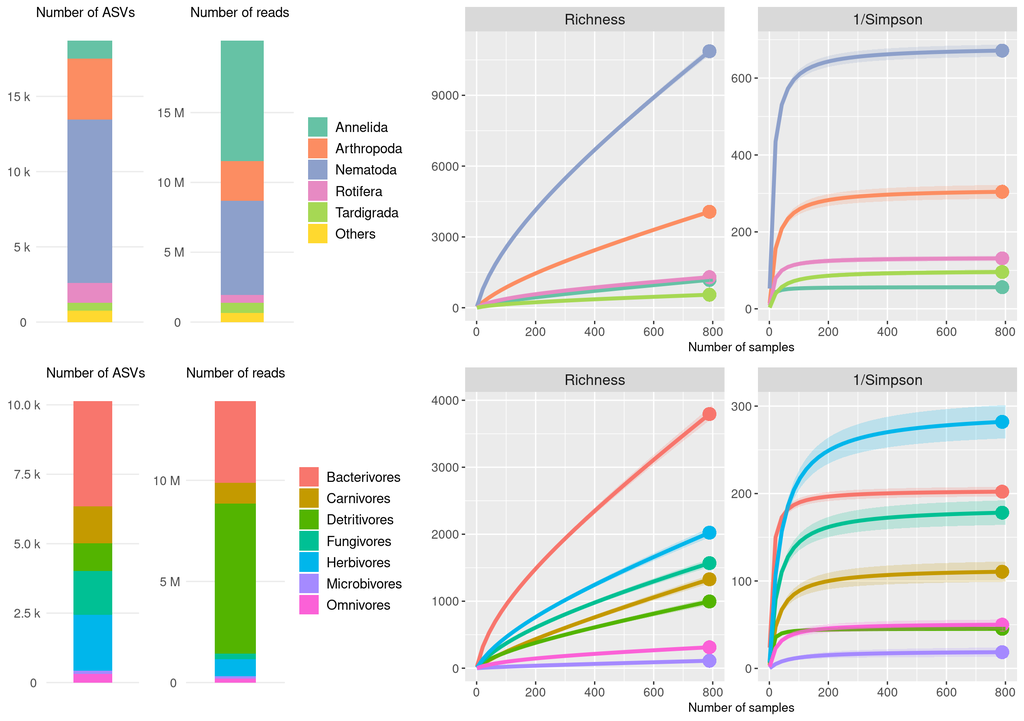

```r
fig1<-ggarrange(
  ggarrange(ggarrange(t1,t2, common.legend = TRUE, legend = "right"),t3, widths = c(1,1.5)),
  ggarrange(ggarrange(g1,g2, common.legend = TRUE, legend = "right"),g3, widths = c(1,1.5)),
  nrow=2
)

print(fig1)
```

```r
ggsave("Figures/Figure_1.pdf", plot = fig1, device="pdf", scale = 1.7,
      width = 180, height = (210/297)*180 , units = "mm", bg="white")
```

## **FIGURE 2**

### Data preparation

```r
# ll <- Table_SplitByTaxa_01
# outl<-list()
# for (i in 1:length(ll)) {
#  df <- ll[[i]]
#  tbl_01 <- SplitTableBySampleMetadataColumn(df,met,"Anthrop")
#  minCol=min(sapply(tbl_01, ncol))
#  res <- iNEXT(tbl_01, q=c(0,2), datatype = "incidence_raw",
#             endpoint = 2*minCol, knots = 40,
#             se = TRUE, conf = 0.95, nboot = 500)
#  outl[[i]] <- res
# }
# names(outl)<-names(ll)
# saveRDS(outl,"RDSs/iNEXT_SplitByTaxa_byAnthrop.rds")
iNEXT_SplitByTaxa_byAnthrop <- readRDS("RDSs/iNEXT_SplitByTaxa_byAnthrop.rds")

# ll <- Table_SplitByTaxa_01
# outl<-list()
# for (i in 1:length(ll)) {
#  df <- ll[[i]]
#  tbl_01 <- SplitTableBySampleMetadataColumn(df,met,"LC_simpl_2018")
#  minCol=min(sapply(tbl_01, ncol))
#  res <- iNEXT(tbl_01, q=c(0,2), datatype = "incidence_raw",
#             endpoint = 2*minCol, knots = 40,
#             se = TRUE, conf = 0.95, nboot = 500)
#  outl[[i]] <- res
# }
# names(outl)<-names(ll)
# saveRDS(outl,"RDSs/iNEXT_SplitByTaxa_byEnvSimpl.rds")
iNEXT_SplitByTaxa_byEnvSimpl <- readRDS("RDSs/iNEXT_SplitByTaxa_byEnvSimpl.rds")


# CroplandSamples<-met[!met$Cropland_spec %in% c("Not_A_Crop","Miscellaneous","Tubers"),]$SampleID
# ll <- Table_SplitByTaxa_01
# outl<-list()
# for (i in 1:length(ll)) {
#  df <- as.data.frame(ll[[i]])
#  df <- df[names(df) %in% CroplandSamples]
#  tbl_01 <- SplitTableBySampleMetadataColumn(df,met,"Tree")
#  names(tbl_01)[names(tbl_01)=="NotTree"] <- "Annual crop"
#  names(tbl_01)[names(tbl_01)=="Tree"] <- "Permanent crop"
#  minCol=min(sapply(tbl_01, ncol))
#  res <- iNEXT(tbl_01, q=c(0,2), datatype = "incidence_raw",
#               endpoint = minCol*2, knots = 40,
#               se = TRUE, conf = 0.95, nboot = 500)
#  outl[[i]] <- res
# }
# names(outl)<-names(ll)
# saveRDS(outl,"RDSs/iNEXT_SplitByTaxa_byCropType.rds")
iNEXT_SplitByTaxa_byCropType <- readRDS("RDSs/iNEXT_SplitByTaxa_byCropType.rds")

titles<-c("Annelida", "Arthropoda", "Nematoda", "Rotifera", "Tardigrada")
```

### **Figure 2A**

```r
# Anthrop
dat<-iNEXT_SplitByTaxa_byAnthrop
plts_2a<-list()
for(i in 1:length(dat)) {
  plts_2a[[i]]<-ggiNEXT(dat[[i]], type = 1,
                       facet.var = "Order.q", color.var = "Assemblage",
                       se = TRUE, grey = FALSE) +
    xlab("") + ylab("") + ggtitle (names(dat)[i]) +
    facet_wrap(~Order.q, scales="free",
               labeller = labeller(
                 Order.q = c("0" = "Richness","2" = "1/Simpson"))) +
    theme(
      axis.text.x = element_text(size = 10),
      axis.text.y = element_text(size = 10),
      strip.text = element_text(size = 12),
      plot.title = element_text(size = 14, hjust = 0.5),
      legend.text = element_text(size = 14)) +
    guides(shape = "none", linetype = "none") +
    ggtitle(titles[i])
}
```

### **Figure 2B**

```r
# EnvSimpl
dat<-iNEXT_SplitByTaxa_byEnvSimpl
plts_2b<-list()
for(i in 1:length(dat)) {
  plts_2b[[i]] <- ggiNEXT(dat[[i]], type = 1,
                         facet.var = "Order.q",
                         color.var = "Assemblage",
                         se = TRUE, grey = FALSE) +
    aes(shape = Assemblage) +
    xlab("") + ylab("") +
    facet_wrap(~Order.q, scales = "free",
               labeller = labeller(
                 Order.q = c("0" = "Richness",
                             "2" = "1/Simpson"))) +
    scale_color_manual(values = c("Cropland" = "#E7298A",
                                  "Grassland" = "#E6AB02",
                                  "Woodland" = "#33A02C")) +
    scale_fill_manual(values = c("Cropland" = "#E7298A",
                                 "Grassland" = "#E6AB02",
                                 "Woodland" = "#33A02C")) +
    scale_shape_manual(values = c("Cropland" = 16,
                                  "Grassland" = 15,
                                  "Woodland" = 1)) +
    theme(
      axis.text.x = element_text(size = 10),
      axis.text.y = element_text(size = 10),
      strip.text = element_text(size = 12),
      plot.title = element_text(size = 14, hjust = 0.5),
      legend.text = element_text(size = 14)) +
    guides(linetype = "none") +
    ggtitle(titles[i])
}
```

### **Figure 2C**

```r
# CropType
dat<-iNEXT_SplitByTaxa_byCropType
plts_2c<-list()
for(i in 1:length(dat)) {
  plts_2c[[i]]<-ggiNEXT(dat[[i]], type = 1,
                       facet.var = "Order.q", color.var = "Assemblage",
                       se = TRUE, grey = FALSE) +
    aes(shape = Assemblage) +
    xlab("") + ylab("") + ggtitle (names(dat)[i]) +
    facet_wrap(~Order.q, scales="free",
               labeller = labeller(
                 Order.q = c("0" = "Richness","2" = "1/Simpson"))) +
    scale_color_manual(values=c("Permanent crop"="#6A3D9A","Annual crop"="#B15928"),
                       labels=c("Annual crop","Perennial crop")) +
    scale_fill_manual(values=c("Permanent crop"="#6A3D9A","Annual crop"="#B15928"),
                       labels=c("Annual crop","Perennial crop")) +
    scale_shape_manual(values = c("Permanent crop" = 18,
                                  "Annual crop" = 15)) +
    theme(
      axis.text.x = element_text(size = 10),
      axis.text.y = element_text(size = 10),
      strip.text = element_text(size = 12),
      plot.title = element_text(size = 14, hjust = 0.5),
      legend.text = element_text(size = 14)) +
    guides(linetype = "none",
           shape = "none") +
    ggtitle(titles[i])
}
```

### **Figure 2 complete**

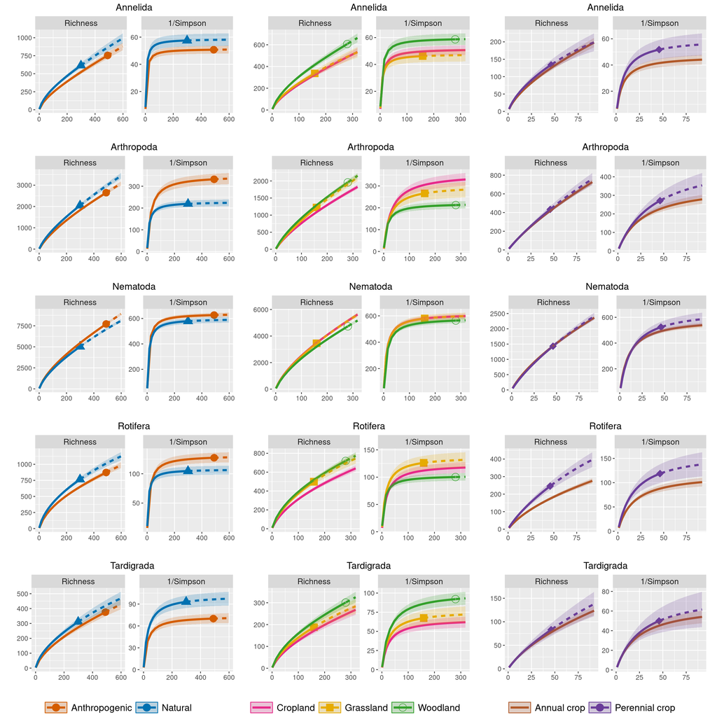

```r
arrPlts_2a<-ggarrange(plotlist = plts_2a, ncol=1, nrow=5, common.legend=TRUE, legend = "bottom")
arrPlts_2b<-ggarrange(plotlist = plts_2b, ncol=1, nrow=5, common.legend=TRUE, legend = "bottom")
arrPlts_2c<-ggarrange(plotlist = plts_2c, ncol=1, nrow=5, common.legend=TRUE, legend = "bottom")

fig2 <- ggarrange(arrPlts_2a,arrPlts_2b,arrPlts_2c, ncol=3, legend = "bottom")

print(fig2)
```

```r
ggsave("Figures/Figure_2.pdf", device="pdf", plot = fig2, scale=1.8,
      width = 180, height = (5/7*297)/210*180, units = "mm", bg="white")
```

## **FIGURE 3**

### Data preparation

```r
# ll <- Table_SplitByGuild_01
# outl<-list()
# for (i in 1:length(ll)) {
#  df <- ll[[i]]
#  tbl_01 <- SplitTableBySampleMetadataColumn(df,met,"Anthrop")
#  minCol=min(sapply(tbl_01, ncol))
#  res <- iNEXT(tbl_01, q=c(0,2), datatype = "incidence_raw",
#             endpoint = 2*minCol, knots = 40,
#             se = TRUE, conf = 0.95, nboot = 500)
#  outl[[i]] <- res
# }
# names(outl)<-names(ll)
# saveRDS(outl,"RDSs/iNEXT_SplitByGuild_byAnthrop.rds")
iNEXT_SplitByGuild_byAnthrop <- readRDS("RDSs/iNEXT_SplitByGuild_byAnthrop.rds")

# ll <- Table_SplitByGuild_01
# outl<-list()
# for (i in 1:length(ll)) {
#  df <- ll[[i]]
#  tbl_01 <- SplitTableBySampleMetadataColumn(df,met,"LC_simpl_2018")
#  minCol=min(sapply(tbl_01, ncol))
#  res <- iNEXT(tbl_01, q=c(0,2), datatype = "incidence_raw",
#             endpoint = 2*minCol, knots = 40,
#             se = TRUE, conf = 0.95, nboot = 500)
#  outl[[i]] <- res
# }
# names(outl)<-names(ll)
# saveRDS(outl,"RDSs/iNEXT_SplitByGuild_byEnvSimpl.rds")
iNEXT_SplitByGuild_byEnvSimpl <- readRDS("RDSs/iNEXT_SplitByGuild_byEnvSimpl.rds")


# CroplandSamples<-met[!met$Cropland_spec %in% c("Not_A_Crop","Miscellaneous","Tubers"),]$SampleID
# ll <- Table_SplitByGuild_01
# outl<-list()
# for (i in 1:length(ll)) {
#  df <- as.data.frame(ll[[i]])
#  df <- df[names(df) %in% CroplandSamples]
#  tbl_01 <- SplitTableBySampleMetadataColumn(df,met,"Tree")
#  names(tbl_01)[names(tbl_01)=="NotTree"] <- "Annual crop"
#  names(tbl_01)[names(tbl_01)=="Tree"] <- "Permanent crop"
#  minCol=min(sapply(tbl_01, ncol))
#  res <- iNEXT(tbl_01, q=c(0,2), datatype = "incidence_raw",
#               endpoint = minCol*2, knots = 40,
#               se = TRUE, conf = 0.95, nboot = 500)
#  outl[[i]] <- res
# }
# names(outl)<-names(ll)
# saveRDS(outl,"RDSs/iNEXT_SplitByGuild_byCropType.rds")
iNEXT_SplitByGuild_byCropType <- readRDS("RDSs/iNEXT_SplitByGuild_byCropType.rds")
```

### **Figure 3A**

```r
# Anthrop
dat<-iNEXT_SplitByGuild_byAnthrop
plts_3a<-list()
for(i in 1:length(dat)) {
  plts_3a[[i]]<-ggiNEXT(dat[[i]], type = 1,
                       facet.var = "Order.q", color.var = "Assemblage",
                       se = TRUE, grey = FALSE) +
    xlab("") + ylab("") + ggtitle (names(dat)[i]) +
    facet_wrap(~Order.q, scales="free",
               labeller = labeller(
                 Order.q = c("0" = "Richness","2" = "1/Simpson"))) +
    theme(
      axis.text.x = element_text(size = 10),
      axis.text.y = element_text(size = 10),
      strip.text = element_text(size = 12),
      plot.title = element_text(size = 14, hjust = 0.5),
      legend.text = element_text(size = 14)) +
    guides(shape = "none", linetype = "none") +
    ggtitle(names(dat)[i])
}
```

### **Figure 3B**

```r
# EnvSimpl
dat<-iNEXT_SplitByGuild_byEnvSimpl
plts_3b<-list()
for(i in 1:length(dat)) {
  plts_3b[[i]]<-ggiNEXT(dat[[i]], type = 1,
                       facet.var = "Order.q", color.var = "Assemblage",
                       se = TRUE, grey = FALSE) +
    aes(shape = Assemblage) +
    xlab("") + ylab("") + ggtitle (names(dat)[i]) +
    facet_wrap(~Order.q, scales="free",
               labeller = labeller(
                 Order.q = c("0" = "Richness","2" = "1/Simpson"))) +
    scale_color_manual(values=c("Cropland"="#E7298A","Grassland"="#E6AB02","Woodland"="#33A02C")) +
    scale_fill_manual(values=c("Cropland"="#E7298A","Grassland"="#E6AB02","Woodland"="#33A02C")) +
    scale_shape_manual(values = c("Cropland" = 16,
                                  "Grassland" = 15,
                                  "Woodland" = 1)) +
    theme(
      axis.text.x = element_text(size = 10),
      axis.text.y = element_text(size = 10),
      strip.text = element_text(size = 12),
      plot.title = element_text(size = 14, hjust = 0.5),
      legend.text = element_text(size = 14)) +
    guides(shape = "none", linetype = "none") +
    ggtitle(names(dat)[i])
}
```

### **Figure 3C**

```r
# CropType
dat<-iNEXT_SplitByGuild_byCropType
plts_3c<-list()
for(i in 1:length(dat)) {
  plts_3c[[i]]<-ggiNEXT(dat[[i]], type = 1,
                       facet.var = "Order.q", color.var = "Assemblage",
                       se = TRUE, grey = FALSE) +
    aes(shape = Assemblage) +
    xlab("") + ylab("") + ggtitle (names(dat)[i]) +
    facet_wrap(~Order.q, scales="free",
               labeller = labeller(
                 Order.q = c("0" = "Richness","2" = "1/Simpson"))) +
    scale_color_manual(values=c("Permanent crop"="#6A3D9A","Annual crop"="#B15928"),
                       labels=c("Annual crop","Perennial crop")) +
    scale_fill_manual(values=c("Permanent crop"="#6A3D9A","Annual crop"="#B15928"),
                       labels=c("Annual crop","Perennial crop")) +
    scale_shape_manual(values = c("Permanent crop" = 18,
                                  "Annual crop" = 15)) +
    theme(
      axis.text.x = element_text(size = 10),
      axis.text.y = element_text(size = 10),
      strip.text = element_text(size = 12),
      plot.title = element_text(size = 14, hjust = 0.5),
      legend.text = element_text(size = 14)) +
    guides(shape = "none", linetype = "none") +
    ggtitle(names(dat)[i])
}
```

### **Figure 3 complete**

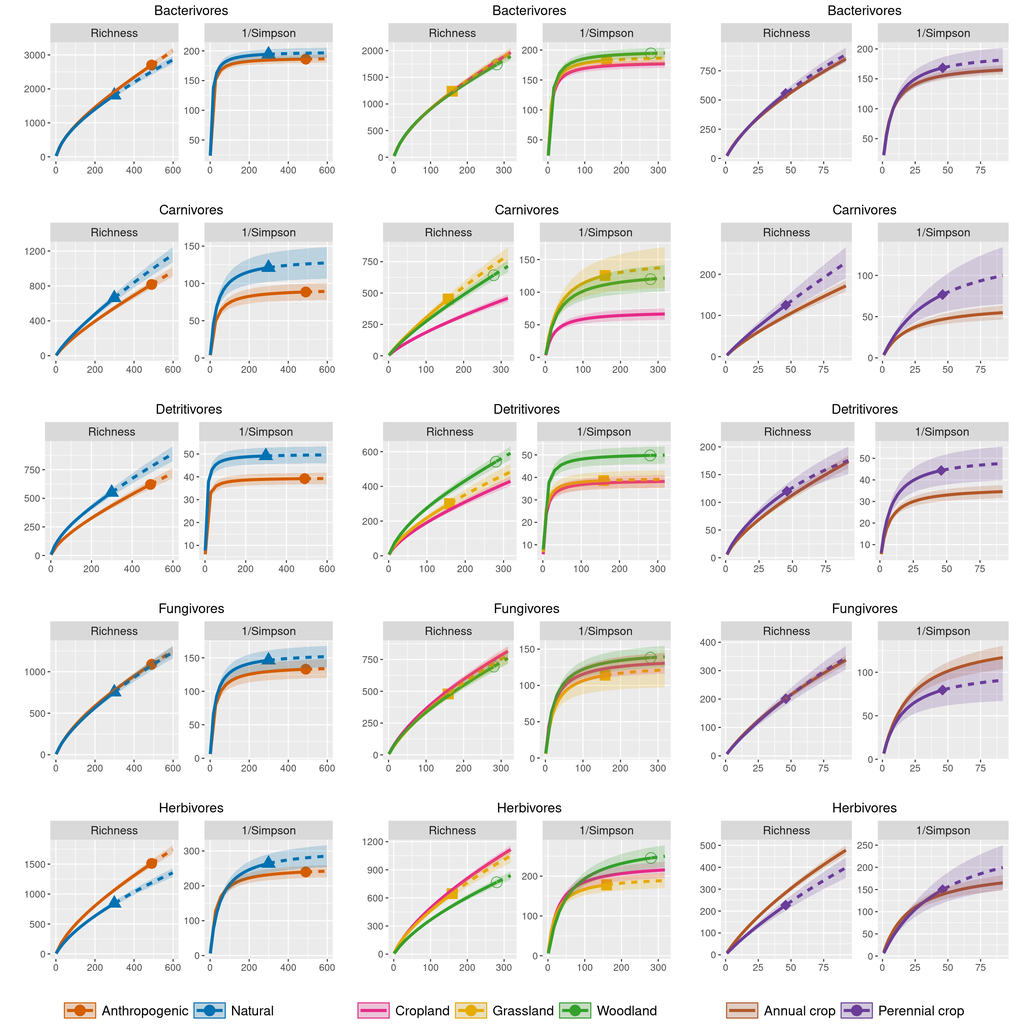

```r
arrPlts_3a<-ggarrange(plotlist = plts_3a[1:5], ncol=1, nrow=5, common.legend=TRUE, legend = "bottom")
arrPlts_3b<-ggarrange(plotlist = plts_3b[1:5], ncol=1, nrow=5, common.legend=TRUE, legend = "bottom")
arrPlts_3c<-ggarrange(plotlist = plts_3c[1:5], ncol=1, nrow=5, common.legend=TRUE, legend = "bottom")

fig3 <- ggarrange(arrPlts_3a,arrPlts_3b,arrPlts_3c, ncol=3, legend = "bottom")

print(fig3)
```

```r
ggsave("Figures/Figure_3.pdf", plot = fig3, device="pdf", scale=1.8,
      width = 180, height = (5/7*297)/210*180, units = "mm", bg="white")
```

## **FIGURE 4**

### Data preparation

Trophic guild log-ratios were calculated using [QURRO](https://github.com/biocore/qurro) ([Fedarko et al., 2020](https://doi.org/10.1093/nargab/lqaa023)) by comparing the summed abundances of features assigned to different guilds. As examples, two comparisons are shown:

- (**detritivores** + **fungivores**) / **herbivores**
- **carnivores** / (**herbivores** + **fungivores**)

```r
# function to remove null log ratios and convert to numeric data type
CleanUp <- function(rat) {
  rat<-rat[!rat$Current_Natural_Log_Ratio == "null",]
  rat$Current_Natural_Log_Ratio<-as.numeric(rat$Current_Natural_Log_Ratio)
  return(rat)
}

# load metadata
met <- read.csv("LUCAS_data/LUCAS_metadata.tsv", header=TRUE, sep="\t", stringsAsFactors = F, check.names = F)

# load log ratios
R1 <- read.csv("LUCAS_data/Ratio_FunDet_VS_Her.tsv", header=TRUE, sep="\t", stringsAsFactors = F, check.names = F)
R2 <- read.csv("LUCAS_data/Ratio_Car_VS_HerFun.tsv", header=TRUE, sep="\t", stringsAsFactors = F, check.names = F)

# clean up
R_1 <- CleanUp(R1[,1:2])
R_2 <- CleanUp(R2[,1:2])

df_1 <- merge(R_1,met, by = "SampleID")
df_2 <- merge(R_2,met, by = "SampleID")

df_1$Anthrop<-factor(df_1$Anthrop, levels=c("Natural", "Anthropogenic"))
df_2$Anthrop<-factor(df_2$Anthrop, levels=c("Natural", "Anthropogenic"))

df_1$LC_simpl_2018<-factor(df_1$LC_simpl_2018,levels=c("Woodland", "Grassland", "Cropland"))
df_2$LC_simpl_2018<-factor(df_2$LC_simpl_2018,levels=c("Woodland", "Grassland", "Cropland"))
```

### **Figure 4A,B,C,D**

```r
# Calculate sample size per group
group_n <- table(df_1$Anthrop)
# Create labels including sample size
group_labels <- c(
  "Anthropogenic" = paste0("Anthropogenic\n(n = ", group_n["Anthropogenic"], ")"),
  "Natural" = paste0("Natural\n(n = ", group_n["Natural"], ")"))
f4a<-ggboxplot(df_1, x = "Anthrop", y = "Current_Natural_Log_Ratio",
          color = "Anthrop", palette = "jco", add = "jitter",
          title = "",
          legend = "right") + xlab("") + ylab("Natural log ratio") +
  stat_compare_means(method = "wilcox.test",
                     label = "p.format",
                     label.x = 1.38) +
  scale_color_manual(values=c("Anthropogenic"="#D55E00","Natural"="#0072B2")) +
  scale_x_discrete(labels = group_labels) +
  theme(legend.title = element_blank(),
        axis.title.x = element_text(size = 10),
        axis.title.y = element_text(size = 18),
        axis.text.x = element_text(size = 18),
        axis.text.y = element_text(size = 12))

# Calculate sample size per group
group_n <- table(df_2$Anthrop)
# Create labels including sample size
group_labels <- c(
  "Anthropogenic" = paste0("Anthropogenic\n(n = ", group_n["Anthropogenic"], ")"),
  "Natural" = paste0("Natural\n(n = ", group_n["Natural"], ")"))
f4b<-ggboxplot(df_2, x = "Anthrop", y = "Current_Natural_Log_Ratio",
          color = "Anthrop", palette = "jco", add = "jitter",
          title = "",
          legend = "right") + xlab("") + ylab("Natural log ratio") +
  stat_compare_means(method = "wilcox.test",
                     label = "p.format",
                     label.x = 1.38) +
  scale_color_manual(values=c("Anthropogenic"="#D55E00","Natural"="#0072B2")) +
  scale_x_discrete(labels = group_labels) +
  theme(legend.title = element_blank(),
        axis.title.x = element_text(size = 10),
        axis.title.y = element_text(size = 18),
        axis.text.x = element_text(size = 18),
        axis.text.y = element_text(size = 12))

stat.test1 <- df_1 %>%
  pairwise_wilcox_test(
    Current_Natural_Log_Ratio ~ LC_simpl_2018,
    p.adjust.method = "BH"
  )

stat.test2 <- df_2 %>%
  pairwise_wilcox_test(
    Current_Natural_Log_Ratio ~ LC_simpl_2018,
    p.adjust.method = "BH"
  )

group_n <- table(df_1$LC_simpl_2018)
# Create labels including sample size
group_labels <- c(
  "Woodland" = paste0("Woodland\n(n = ", group_n["Woodland"], ")"),
  "Grassland" = paste0("Grassland\n(n = ", group_n["Grassland"], ")"),
  "Cropland" = paste0("Cropland\n(n = ", group_n["Cropland"], ")"))
my_comparisons <- list( c("Woodland", "Grassland"), c("Woodland", "Cropland"), c("Grassland", "Cropland") )
f4c<-ggboxplot(df_1, x = "LC_simpl_2018", y = "Current_Natural_Log_Ratio",
          color = "LC_simpl_2018", palette = "jco", add = "jitter",
          title = "",
          legend = "right") + xlab("") + ylab("Natural log ratio") +
  stat_signif(comparisons = my_comparisons,
              annotations = paste0("p = ", format.pval(stat.test1$p.adj, digits = 2)),
              map_signif_level = FALSE,
              step_increase = 0.1) +
  scale_color_manual(values=c("Cropland"="#E7298A","Grassland"="#E6AB02","Woodland"="#33A02C")) +
  scale_x_discrete(labels = group_labels) +
  theme(legend.title = element_blank(),
        axis.title.x = element_text(size = 10),
        axis.title.y = element_text(size = 18),
        axis.text.x = element_text(size = 18),
        axis.text.y = element_text(size = 12))


group_n <- table(df_2$LC_simpl_2018)
# Create labels including sample size
group_labels <- c(
  "Woodland" = paste0("Woodland\n(n = ", group_n["Woodland"], ")"),
  "Grassland" = paste0("Grassland\n(n = ", group_n["Grassland"], ")"),
  "Cropland" = paste0("Cropland\n(n = ", group_n["Cropland"], ")"))
f4d<-ggboxplot(df_2, x = "LC_simpl_2018", y = "Current_Natural_Log_Ratio",
          color = "LC_simpl_2018", palette = "jco", add = "jitter",
          title = "",
          legend = "right") + xlab("") + ylab("Natural log ratio") +
  stat_signif(comparisons = my_comparisons,
              annotations = paste0("p = ", format.pval(stat.test2$p.adj, digits = 2)),
              map_signif_level = FALSE,
              step_increase = 0.1) +
  scale_color_manual(values=c("Cropland"="#E7298A","Grassland"="#E6AB02","Woodland"="#33A02C")) +
  scale_x_discrete(labels = group_labels) +
  theme(legend.title = element_blank(),
        axis.title.x = element_text(size = 10),
        axis.title.y = element_text(size = 18),
        axis.text.x = element_text(size = 18),
        axis.text.y = element_text(size = 12))


fig4_top<-ggarrange(
  ggarrange(f4a,f4b, nrow=1, legend="none"),
  ggarrange(f4c,f4d, nrow=1, legend="none"),
  nrow=2
)
```

### **Figure 4E,F**

```r
# 75 LUCAS samples shared an identical bulk density value (1.067405006), while no other sample shared identical values. These samples were therefore considered artifactual and removed
ddf_1<-df_1[df_1$Bulk_density!=1.067405006,]
ddf_2<-df_2[df_2$Bulk_density!=1.067405006,]
# Also 1 samples with bulk density value (4.55) more than twice the maximum of other samples is considered an outlier and removed
ddf_1<-ddf_1[ddf_1$Bulk_density<1.8,]
ddf_2<-ddf_2[ddf_2$Bulk_density<1.8,]
# Extract only woodland samples
ddf_1<-ddf_1[ddf_1$LC_simpl_2018=="Woodland",]
ddf_2<-ddf_2[ddf_2$LC_simpl_2018=="Woodland",]

f4e<-ggscatter(ddf_1, x = "Bulk_density", y = "Current_Natural_Log_Ratio",
          add = "loess",                         # Add regression line
          conf.int = TRUE,
          title = "") +
  stat_cor(aes(label = after_stat(p.label)), label.y = 10, p.accuracy = 0.0001, output.type = "text") +
  ylab("Natural log ratio") + xlab(expression("Bulk density (g/" * cm^3 * ")")) +
  theme(
        axis.title.x = element_text(size = 18),
        axis.title.y = element_text(size = 18),
        axis.text.x = element_text(size = 12),
        axis.text.y = element_text(size = 12))
f4f<-ggscatter(ddf_2, x = "Bulk_density", y = "Current_Natural_Log_Ratio",
          add = "loess",                         # Add regression line
          conf.int = TRUE,
          title = "") +
  stat_cor(aes(label = after_stat(p.label)), label.y = 1, p.accuracy = 0.0001, output.type = "text") +
  ylab("Natural log ratio") + xlab(expression("Bulk density (g/" * cm^3 * ")")) +
  theme(
        axis.title.x = element_text(size = 18),
        axis.title.y = element_text(size = 18),
        axis.text.x = element_text(size = 12),
        axis.text.y = element_text(size = 12))


fig4_bottom<-ggarrange(f4e,f4f,ncol=2, legend="none")
```

### **Figure 4 complete**

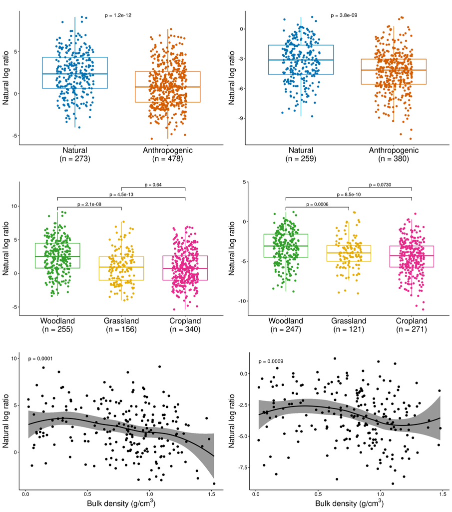

```r
fig4<-ggarrange(fig4_top,fig4_bottom,nrow=2, heights = c(2,1))

print(fig4)
```

```r
ggsave("Figures/Figure_4.pdf", plot = fig4, device="pdf", scale=1.8,
       width = 180, height = (0.8*297)/210*180, units = "mm", bg="white")
```

## **Supplementary figure 1**

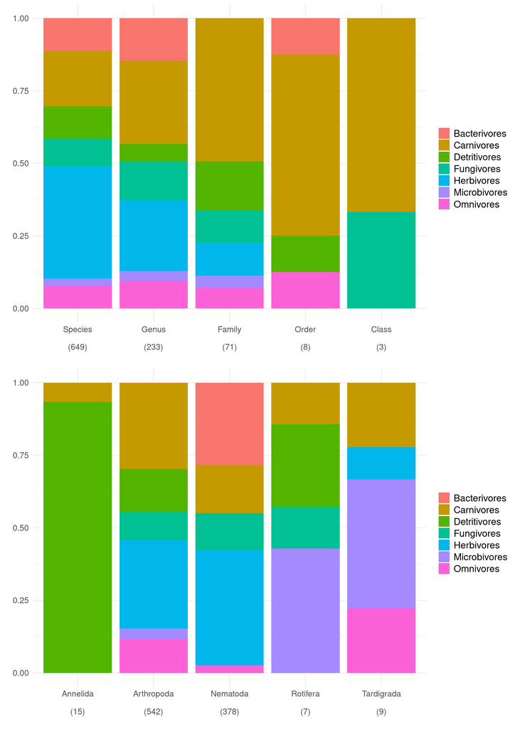

```r
dat <- read.table("INVGuild.tsv", header=TRUE, sep="\t", stringsAsFactors = F, check.names = F)
data <- dat[,c(1,4,5)]
data <- data[!is.na(data$Taxonomic_level),]
data <- data[!is.na(data$Ecology),]

desired_order <- rev(c("Class", "Order", "Family", "Genus", "Species"))

data$Taxonomic_level <- factor(
  data$Taxonomic_level,
  levels = desired_order
)
level_counts <- data %>%
  count(Taxonomic_level)
x_labels <- setNames(
  paste0(level_counts$Taxonomic_level, "\n\n(",
         level_counts$n, ")"),
  level_counts$Taxonomic_level
)
sf1a<-ggplot(data, aes(x = Taxonomic_level, fill = Ecology)) +
  geom_bar(position = "fill") +
  labs(x = "",y = "",fill = "") +
  scale_x_discrete(labels = x_labels) +
  theme_minimal() +
  theme(axis.text.x = element_text(size = 12),
        axis.text.y = element_text(size = 12),
        legend.text = element_text(size = 14))


phyla <- c("Annelida", "Arthropoda", "Nematoda",
           "Rotifera", "Tardigrada")
data_filtered <- data %>%
  mutate(Phylum = str_extract(Taxon, "(?<=p__)[^;]+")) %>%
  filter(Phylum %in% phyla)
data_filtered$Phylum <- factor(
  data_filtered$Phylum,
  levels = phyla
)
level_counts2 <- data_filtered %>%
  count(Phylum)
x_labels2 <- setNames(
  paste0(level_counts2$Phylum, "\n\n(",
         level_counts2$n, ")"),
  level_counts2$Phylum
)
sf1b<-ggplot(data_filtered, aes(x = Phylum, fill = Ecology)) +
  geom_bar(position = "fill") +
  scale_x_discrete(labels = x_labels2) +
  labs(x = "",y = "",fill = "") +
  theme_minimal() +
  theme(axis.text.x = element_text(size = 12),
        axis.text.y = element_text(size = 12),
        legend.text = element_text(size = 14))

sfig1<-ggarrange(sf1a,sf1b, nrow = 2)

print(sfig1)
```

```r
ggsave("Figures/Supplementary_Figure_1.pdf", plot=sfig1, device="pdf", scale=1.2,
       width = 180, height = 297/210*180, units = "mm", bg="white")
```

## **Supplementary Figure 2**

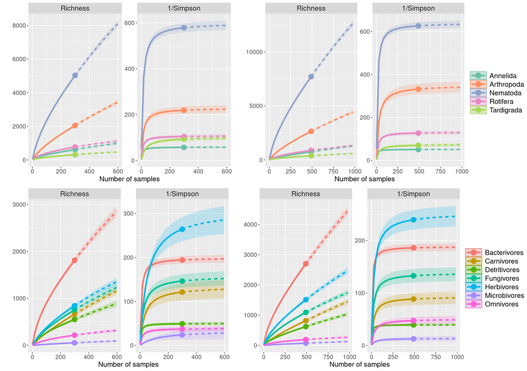

```r
# # Taxa
# tt <- SplitTableBySampleMetadataColumn(tab,met,"Anthrop")
# tt_01 <- MakeBinary(tt)
# ll<-tt_01
# outl<-list()
# for (i in 1:length(ll)) {
#  df <- ll[[i]]
#  tbl_01 <- SplitTableByFeatureMetadataColumn(df, tmtd[tmtd$TaxGroup %in% Names_Taxa,], "TaxGroup")
#  minCol=min(sapply(tbl_01, ncol))
#  res <- iNEXT(tbl_01, q=c(0,2), datatype = "incidence_raw",
#               endpoint = 2*minCol, knots = 40,
#               se = TRUE, conf = 0.95, nboot = 500)
#  outl[[i]] <- res
# }
# names(outl)<-names(ll)
# saveRDS(outl,"RDSs/iNEXT_FullTableByAnthrop_ByTaxa.rds")
iNEXT_FullTableByAnthrop_ByTaxa <- readRDS("RDSs/iNEXT_FullTableByAnthrop_ByTaxa.rds")

# # Trophic guilds
# tbl<-tab[row.names(tab) %in% fmtd$Feature.ID,]
# tt <- SplitTableBySampleMetadataColumn(tbl,met,"Anthrop")
# tt_01 <- MakeBinary(tt)
# ll<-tt_01
# outl<-list()
# for (i in 1:length(ll)) {
#  df <- ll[[i]]
#  tbl_01 <- SplitTableByFeatureMetadataColumn(df, fmtd, "guild")
#  minCol=min(sapply(tbl_01, ncol))
#  res <- iNEXT(tbl_01, q=c(0,2), datatype = "incidence_raw",
#               endpoint = 2*minCol, knots = 40,
#               se = TRUE, conf = 0.95, nboot = 500)
#  outl[[i]] <- res
# }
# names(outl)<-names(ll)
# saveRDS(outl,"RDSs/iNEXT_FullTableByAnthrop_ByGuild.rds")
iNEXT_FullTableByAnthrop_ByGuild <- readRDS("RDSs/iNEXT_FullTableByAnthrop_ByGuild.rds")


# Supplementary figure 2A,B
dd<-iNEXT_FullTableByAnthrop_ByTaxa
plts_1<-list()
for(i in 1:length(dd)) {
  plts_1[[i]]<-ggiNEXT(dd[[i]], type = 1,
                       facet.var = "Order.q", color.var = "Assemblage",
                       se = TRUE, grey = FALSE) +
    xlab("Number of samples") + ylab("") +
    facet_wrap(~Order.q, scales="free",
               labeller = labeller(
                 Order.q = c("0" = "Richness","2" = "1/Simpson"))) +
    theme(axis.text.x = element_text(size = 12),
          axis.text.y = element_text(size = 12),
          axis.title.x = element_text(size = 14),
          strip.text = element_text(size = 14),
          legend.text = element_text(size = 14)) +
    guides(shape = "none", linetype = "none") +
    scale_color_brewer(palette = "Set2",
                       labels = function(x) gsub("^p__", "", gsub("p__Nematozoa", "p__Nematoda", x))) +
    scale_fill_brewer(palette = "Set2",
                      labels = function(x) gsub("^p__", "", gsub("p__Nematozoa", "p__Nematoda", x))) +
    scale_shape_manual(values = rep(16,5))
}

# Supplementary figure 2C,D
dd<-iNEXT_FullTableByAnthrop_ByGuild
plts_2<-list()
for(i in 1:length(dd)) {
  plts_2[[i]]<-ggiNEXT(dd[[i]], type = 1,
                       facet.var = "Order.q", color.var = "Assemblage",
                       se = TRUE, grey = FALSE) +
    xlab("Number of samples") + ylab("") +
    facet_wrap(~Order.q, scales="free",
               labeller = labeller(
                 Order.q = c("0" = "Richness","2" = "1/Simpson"))) +
    theme(axis.text.x = element_text(size = 12),
          axis.text.y = element_text(size = 12),
          axis.title.x = element_text(size = 14),
          strip.text = element_text(size = 14),
          legend.text = element_text(size = 14)) +
    guides(shape = "none", linetype = "none") +
    scale_color_hue() +
    scale_fill_hue() +
    scale_shape_manual(values = rep(16,7))
}


# Supplementary figure 2 complete
sfig2 <- ggarrange(
  ggarrange(plts_1[[2]],plts_1[[1]], ncol=2, common.legend = T, legend = "right"),
  ggarrange(plts_2[[2]],plts_2[[1]], ncol=2, common.legend = T, legend = "right"),
  nrow=2)

print(sfig2)
```

```r
ggsave("Figures/Supplementary_Figure_2.pdf", plot = sfig2, device="pdf", scale=2,
       width = 180, height = 148/210*180, units = "mm", bg="white")
```

## **Supplementary Figure 3**

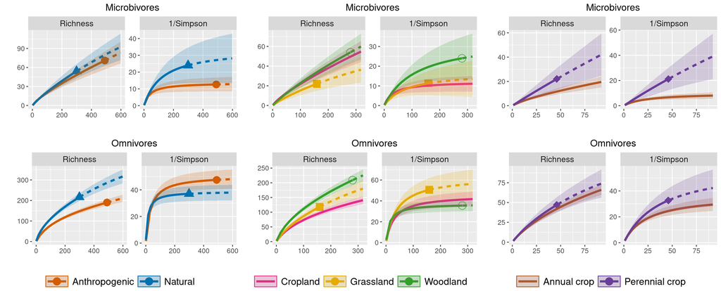

```r
arrPlts_s3a<-ggarrange(plotlist = plts_3a[6:7], ncol=1, nrow=2, common.legend=TRUE, legend = "bottom")
arrPlts_s3b<-ggarrange(plotlist = plts_3b[6:7], ncol=1, nrow=2, common.legend=TRUE, legend = "bottom")
arrPlts_s3c<-ggarrange(plotlist = plts_3c[6:7], ncol=1, nrow=2, common.legend=TRUE, legend = "bottom")

sfig3 <- ggarrange(arrPlts_s3a,arrPlts_s3b,arrPlts_s3c, ncol=3, legend = "bottom")

print(sfig3)
```

```r
ggsave("Figures/Supplementary_Figure_3.pdf", plot = sfig3, device="pdf", scale=1.8,
       width = 180, height = (2/7*297)/210*180, units = "mm", bg="white")
```